# Analysis of Vehicular Accidents in the United States

**Collaborators: Monish Napa and Prateek Akula**

## Introduction

Car crashes are one of the leading causes of accidents in the United States. According to the [Insurance Institute for Highway Safety](https://www.iihs.org/topics/fatality-statistics/detail/state-by-state), there were nearly 40,000 car crashes in the United States in 2021 alone, in which over 42,000 fatalities occured. This resulted in a death rate of up to 12.9 per 100,000 people on average, with some states such as Mississippi reaching even 26.2. Such rates are alarming as they call for a need to regulate highway and driving laws across the country through political and economic changes.

**For more information about car accidents and relevant policies in the United States, please visit:**

- [NHTSA Database](https://www.nhtsa.gov/data/national-center-statistics-and-analysis)
- [US Laws and Regulations](https://www.nhtsa.gov/laws-regulations)
- [Department of Transporation Reports](https://crashstats.nhtsa.dot.gov/#/)

This project aims to analyze the factors that contribute to vehicular accidents in the United States by collecting and processing data across US states regarding vehicular incidents and performing data exploration and analysis in order to determine how strongly certain factors contribute to rising vehicle accidents. With the preprocessed data and formed hypotheses, we will create machine learning models using both classification and regression to prediccar accident severity given different factors and how fatalities will progress in an unexplored year. By gathering these insights, we can provide suggestive measures using conclusive data analysis to mitigating the risks associated with crashes by pointing attention to certain factors that need to be addressed.

This project walks through the following steps in the data science pipeline:

1. Data Curation
2. Data Preprocessing and Parsing
3. Exploratory Data Analysis
4. Hypothesis Testing
5. Machine Learning
6. Insights and Discoverieses

## Data Curation

Data curation involves collecting and integrating data from across various established sources. For comprehensive and reliable data regarding vehicular incidents across the United States, we will be using the following databases from the National Highway Safety and Traffic Administration to gather information about vehicle ratings and safety related issues that are directly related to issues with vehicle operations:

- [NHTSA Crash Viewer API](https://crashviewer.nhtsa.dot.gov/CrashAPI)
- [NHTSA Datasets and APIs](https://www.nhtsa.gov/nhtsa-datasets-and-apis)

As behavioral and other situational factors are also key indicators of crash likelihood, we will also be using the Crash Viewer from the NHSTA to pull general information across a specified time period about crash details, occupants, and other specific variables that are involved in crashes. As 2019-2020 has the most abundant amount of data among recent years, it will be used for the time period of vehicular accidents.

Data will be collected using API calls to NHSTA databases that use parameters such as year, state id, etc. to perform query operations. The results are then stored as csv files that can be accessed any time to be used for data processing. For more information about using APIs to perform data collection, please visit:

- [Requests API Guide](https://realpython.com/python-requests/)
- [Convert Information into Pandas Dataframe](https://deallen7.medium.com/how-to-create-a-pandas-dataframe-from-an-api-endpoint-in-a-jupyter-notebook-f2561f766ca3)

The following imports will be made for data curation, processing, and machine learning development:

```python
# For API calls
import requests
from io import StringIO
# For data storage and processing
import pandas as pd
import numpy as np
# For graphical operations
import matplotlib.pyplot as plt
import seaborn as sns
# For hypothesis testing
import statsmodels.api as sm
# For machine learning development and evaluation
from sklearn.model_selection import train_test_split
from sklearn.metrics import mean_squared_error
from sklearn.svm import SVC
from sklearn.metrics import classification_report, accuracy_score
from sklearn.preprocessing import StandardScaler
from sklearn.ensemble import RandomForestClassifier
from sklearn.neighbors import KNeighborsClassifier
from sklearn.pipeline import make_pipeline
from sklearn.preprocessing import PolynomialFeatures
# Miscellaneous
import warnings
```

The first data set utilizes the Crash Data API to perform queries on crash cases given the year range, relevant states, and max range of vehicles present at the crash (which will be limited to 6), returning relevant statistics regarding the number of pedestrians involved, vehicles present, fatalities, and more. For this dataset, responses will be broken down into batches of states, as each response only takes up to 5,000 responses for a given number of states within a certain time period. Therefore, 10 different datasets will store each batch of states. The states contained in each dataset are labelled below.

```python
# Alabama, Alaska, Arizona, Arkansas, California
response = requests.get("https://crashviewer.nhtsa.dot.gov/CrashAPI/crashes/GetCaseList?states=1,2,4,5,6&fromYear=2019&toYear=2020&minNumOfVehicles=1&maxNumOfVehicles=6&format=csv")
crashes1_df = pd.read_csv(StringIO(response.text))
# Colorado, Connecticut, Delaware, District of Columbia, Florida, Georgia
response = requests.get("https://crashviewer.nhtsa.dot.gov/CrashAPI/crashes/GetCaseList?states=8,9,10,11,12&fromYear=2019&toYear=2020&minNumOfVehicles=1&maxNumOfVehicles=6&format=csv")
crashes2_df = pd.read_csv(StringIO(response.text))
#Georgia, Hawaii, Idaho, Illinois
response = requests.get("https://crashviewer.nhtsa.dot.gov/CrashAPI/crashes/GetCaseList?states=13,15,16,17&fromYear=2019&toYear=2020&minNumOfVehicles=1&maxNumOfVehicles=6&format=csv")
crashes3_df = pd.read_csv(StringIO(response.text))
#Indiana, Iowa, Kansas, Kentucky, Louisiana
response = requests.get("https://crashviewer.nhtsa.dot.gov/CrashAPI/crashes/GetCaseList?states=18,19,20,21,22,23&fromYear=2019&toYear=2020&minNumOfVehicles=1&maxNumOfVehicles=6&format=csv")
crashes4_df = pd.read_csv(StringIO(response.text))
#Maryland, Massachusetts, Michigan, Minnesota, Mississippi
response = requests.get("https://crashviewer.nhtsa.dot.gov/CrashAPI/crashes/GetCaseList?states=24,25,26,27,28&fromYear=2019&toYear=2020&minNumOfVehicles=1&maxNumOfVehicles=6&format=csv")
crashes5_df = pd.read_csv(StringIO(response.text))
#Missouri, Montana, Nebraska, Nevada, New Hampshire
response = requests.get("https://crashviewer.nhtsa.dot.gov/CrashAPI/crashes/GetCaseList?states=29,30,31,32,33&fromYear=2019&toYear=2020&minNumOfVehicles=1&maxNumOfVehicles=6&format=csv")
crashes6_df = pd.read_csv(StringIO(response.text))
#New Jersey, New Mexico, New York, North Carolina
response = requests.get("https://crashviewer.nhtsa.dot.gov/CrashAPI/crashes/GetCaseList?states=34,35,36,37&fromYear=2019&toYear=2020&minNumOfVehicles=1&maxNumOfVehicles=6&format=csv")
crashes7_df = pd.read_csv(StringIO(response.text))
# North Dakota, Ohio, Oklahoma, Oregon, Pennsylvania
response = requests.get("https://crashviewer.nhtsa.dot.gov/CrashAPI/crashes/GetCaseList?states=38,39,40,41,42&fromYear=2019&toYear=2020&minNumOfVehicles=1&maxNumOfVehicles=6&format=csv")
crashes8_df = pd.read_csv(StringIO(response.text))
#Puerto Rico, Rhode Island, South Carolina, South Dakota, Tennessee, Texas
response = requests.get("https://crashviewer.nhtsa.dot.gov/CrashAPI/crashes/GetCaseList?states=43,44,45,46,47,48&fromYear=2019&toYear=2020&minNumOfVehicles=1&maxNumOfVehicles=6&format=csv")
crashes9_df = pd.read_csv(StringIO(response.text))
#Utah, Vermont, Virginia, Virgin Islands, Washington, West Virginia, Wisconsin, Wyoming
response = requests.get("https://crashviewer.nhtsa.dot.gov/CrashAPI/crashes/GetCaseList?states=49,50,51,52,53,54,55,56&fromYear=2019&toYear=2020&minNumOfVehicles=1&maxNumOfVehicles=6&format=csv")
crashes10_df = pd.read_csv(StringIO(response.text))
```

```python
crashes_df = pd.concat([crashes1_df, crashes2_df, crashes3_df, crashes4_df, crashes5_df, crashes6_df, crashes7_df, crashes8_df, crashes9_df, crashes10_df],
                       ignore_index=True)
crashes_df.head()
```

|  | st_case | crashdate | state | statename | countyname | totalvehicles | fatals | persons | peds |
| --- | --- | --- | --- | --- | --- | --- | --- | --- | --- |
| 0 | 10701 | 11/11/2020 3:37 PM | 1 | Alabama | MADISON (89) | 1 | 1 | 3 | 0 |
| 1 | 10702 | 10/10/2020 6:32 PM | 1 | Alabama | JEFFERSON (73) | 1 | 1 | 2 | 0 |
| 2 | 10703 | 11/3/2020 7:14 PM | 1 | Alabama | JEFFERSON (73) | 3 | 1 | 6 | 0 |
| 3 | 10704 | 10/18/2020 2:15 AM | 1 | Alabama | JEFFERSON (73) | 2 | 1 | 1 | 0 |
| 4 | 10705 | 10/29/2020 6:32 PM | 1 | Alabama | MADISON (89) | 1 | 1 | 1 | 1 |

## Data Preprocessing and Parsing

Data preprocessing involves performing operations to clean data in order to perform visualization and evaluation without disparities in the data including conflicting units, missing data, or other inconsistencies. For both datasets, data preprocessing will be made in order to perform data parsing, which is the process of extracting the physical data and performing evaluation.

**For more information about data preprocessing using dataframes, please visit:**

- [Cleaning a Dataframe Using Numpy](https://realpython.com/python-data-cleaning-numpy-pandas/)
- [Preprocesing Commands for a Pandas Dataframe](https://connectjaya.com/data-cleaning-and-preprocessing-with-pandas/)

To begin, the crashes datasets will be filtered to a new dataframe that includes columns containing information about the state id and aggregate number of fatalities per state.

```python
combined_df = pd.DataFrame()

state_ids = []
statenames = []
sums = []

state_ids = (crashes_df["state"].unique())
statenames = (crashes_df["statename"].unique())
# Store the sums of each state's fatalities by grouping each state by their unique state id and calculating .sum()
for state in state_ids:
    sums.append(crashes_df[crashes_df["state"] == state]["fatals"].sum())

#sums = [x for x in avgs if x != 0]
combined_df["state_id"] = state_ids
combined_df["statename"] = statenames
combined_df["fatalities"] = sums
# Store the state id, name, and number of fatalities in a combined_df and sort from highest to least aggregate fatalities
combined_df = combined_df.sort_values(by="fatalities", ascending=False)
combined_df.head()
```

|  | state_id | statename | fatalities |
| --- | --- | --- | --- |
| 9 | 12 | Florida | 3319 |
| 10 | 13 | Georgia | 3145 |
| 34 | 39 | Ohio | 2376 |
| 42 | 47 | Tennessee | 2350 |
| 21 | 26 | Michigan | 2070 |

Since we are primarily interested in areas where the most crashes occured, we will collect additional information about these filtered states using another API call that gathers report information regarding the specific case. We will create a new dataframe with report specific information about the most prevalent cases in each of these high fatality states.

```python
# Gather information for the top 5 states with highest fatalities in 2019
states = []
for ind, row in combined_df[:5].iterrows():
    states.append(row["state_id"])

accidents_df = pd.DataFrame()
# For each of these 5 highest states, perform a request that uses the state id in its query to gather general information about every case from that state
# and store each in a dataframe by parsing the text as a csv file
for state in states:
    response = requests.get(f"https://crashviewer.nhtsa.dot.gov/CrashAPI/FARSData/GetFARSData?dataset=Accident&FromYear=2019&ToYear=2020&State={state}&format=csv")
    accidents_df = pd.concat([accidents_df, pd.read_csv(StringIO(response.text))])
```

Next, we will perform preprocessing to the accidents dataframe to remove rows containing missing values and filter columns based on most relevant criteria. Based on the descriptions of each column, the most relevant to consider are statename, ve_total, pvh_invl, peds, pernotmvit, persons, type_int, wrk_zone, road_fnc, nhs, rur_urb, hour, hourname, sp_jur, harm_ev, harm_evname, man_coll, man_collname, weather1, weather2, sch_bus, rail, cf1, cf2, cf3, fatals, and drunk_dr, which are all specific elements that are related to the number of people, time and setting, and additional factors associated with each crash.

While there may be NaN values present in the columns due to some contributing factors (cf1, cf2, cf3) not being present, we will still consider these rows as the other columns provide valuable information about additional contributing factors that are not as apparent.

```python
print(accidents_df.columns)
accidents_df = accidents_df[["statename", "state", "st_case", "ve_total", "pvh_invl", "peds", "pernotmvit", "persons", "typ_int", "wrk_zone", "road_fnc",
"nhs", "rur_urb", "hour", "hourname", "sp_jur", "harm_ev", "harm_evname", "man_coll", "man_collname", "weather1", "weather2", "sch_bus",
"rail", "cf1", "cf1name", "cf2", "cf2name", "cf3", "cf3name", "fatals", "drunk_dr"]]
accidents_df.head()
```

```
Index(['caseyear', 'state', 'st_case', 'statename', 've_total', 've_forms',
       'pvh_invl', 'peds', 'pernotmvit', 'permvit', 'persons', 'county',
       'countyname', 'city', 'cityname', 'day', 'month', 'monthname', 'year',
       'day_week', 'day_weekname', 'hour', 'hourname', 'minute', 'minutename',
       'nhs', 'nhsname', 'rur_urb', 'rur_urbname', 'func_sys', 'func_sysname',
       'rd_owner', 'rd_ownername', 'route', 'routename', 'tway_id', 'tway_id2',
       'milept', 'mileptname', 'latitude', 'latitudename', 'longitud',
       'longitudname', 'sp_jur', 'sp_jurname', 'harm_ev', 'harm_evname',
       'man_coll', 'man_collname', 'reljct1', 'reljct1name', 'reljct2',
       'reljct2name', 'typ_int', 'typ_intname', 'wrk_zone', 'wrk_zonename',
       'road_fnc', 'road_fncname', 'rel_road', 'rel_roadname', 'lgt_cond',
       'lgt_condname', 'weather1', 'weather1name', 'weather2', 'weather2name',
       'weather', 'weathername', 'sch_bus', 'sch_busname', 'rail', 'railname',
       'not_hour', 'not_hourname', 'not_min', 'not_minname', 'arr_hour',
       'arr_hourname', 'arr_min', 'arr_minname', 'hosp_hr', 'hosp_hrname',
       'hosp_mn', 'hosp_mnname', 'cf1', 'cf1name', 'cf2', 'cf2name', 'cf3',
       'cf3name', 'fatals', 'drunk_dr'],
      dtype='object')
```

|  | statename | state | st_case | ve_total | pvh_invl | peds | pernotmvit | persons | typ_int | wrk_zone | ... | sch_bus | rail | cf1 | cf1name | cf2 | cf2name | cf3 | cf3name | fatals | drunk_dr |
| --- | --- | --- | --- | --- | --- | --- | --- | --- | --- | --- | --- | --- | --- | --- | --- | --- | --- | --- | --- | --- | --- |
| 0 | Florida | 12 | 120001 | 2 | 0 | 0 | 0 | 3 | 1 | 0 | ... | 0 | 0000000 | 0.0 | NaN | 0.0 | NaN | 0.0 | NaN | 1 | 1 |
| 1 | Florida | 12 | 120002 | 1 | 0 | 0 | 0 | 1 | 1 | 0 | ... | 0 | 0000000 | 0.0 | NaN | 0.0 | NaN | 0.0 | NaN | 1 | 1 |
| 2 | Florida | 12 | 120003 | 2 | 0 | 0 | 0 | 2 | 1 | 0 | ... | 0 | 0000000 | 0.0 | NaN | 0.0 | NaN | 0.0 | NaN | 1 | 0 |
| 3 | Florida | 12 | 120004 | 1 | 0 | 1 | 1 | 2 | 1 | 0 | ... | 0 | 0000000 | 0.0 | NaN | 0.0 | NaN | 0.0 | NaN | 1 | 0 |
| 4 | Florida | 12 | 120005 | 4 | 0 | 0 | 0 | 4 | 1 | 0 | ... | 0 | 0000000 | 14.0 | Motor Vehicle struck by falling cargo,or somet... | 0.0 | NaN | 0.0 | NaN | 1 | 0 |

5 rows × 32 columns

Next, we will create a dataframe from the accidents dataframe that interacts with the Vehicles API, which collects information regarding the ratings of vehicles. By gathering the state names and cases associated with the accidents, we will be able to gather the information about the vehicles present in the crash using the GetCaseDetails API call, which can then be used in the SafetyRatings call to output a list of the safety ratings corresponding to each car involved in the crash.

Due to the number of operations and API calls that are made in the following blocks of code, the code has been commented out and the results are stored in a csv file that is accessible in the "data" folder of the repository. The code works by creating a dictionary that stores case ids as keys and vehicle ids associated with the case as values for each case number, which are retrieved from the GetCaseDetails API, and missing values are accounted for by skipping over cases where no vehicle information is provided

```python
# cases = {}
# session = requests.Session()
# for ind, row in accidents_df.iterrows():
#     state = row["state"]
#     casename = row["st_case"]
#     response = session.get(f"https://crashviewer.nhtsa.dot.gov/CrashAPI/crashes/GetCaseDetails?stateCase={casename}&caseYear=2019&state={state}&format=json")
#     if response.json()["Results"]:
#         for result in response.json()["Results"]:
#             ids = []
#             for result2 in result:
#                 for case in result2["CrashResultSet"]["Vehicles"]:
#                     res = session.get(f"https://api.nhtsa.gov/SafetyRatings/modelyear/{case['MOD_YEAR']}/make/{case['MAKENAME']}/model/{case['MODELNAME']}")
#                     if res and res.json()["Results"]:
#                         for res in res.json()["Results"]:
#                             ids.append(res["VehicleId"])
#                             cases[casename] = ids
```

Once the dictionary is created, a pandas dataframe is made that stores the ratings of the vehicle in terms of various different metrics in each row and the case number associated with each vehicle is stored in an array that will be appended to the dataframe as a column. This will provide easy access to specific cases and can contribute to an understanding of how safety ratings can play a role in car accidents.

```python
# df = pd.DataFrame()
# casenames = []
# session = requests.Session()
# for key, val in cases.items():
#     for id in val:
#         response = session.get(f"https://api.nhtsa.gov/SafetyRatings/VehicleId/{id}")
#         print(response.content)
#         df = pd.concat([df, pd.DataFrame.from_dict(response.json()["Results"])], ignore_index=True)
#         casenames.append(key)
# session.close()
```

```python
#df["Case Name"] = casenames
#df.to_csv("data/ratings.csv")
```

The last step in the data cleaning process is to remove final missing values from the newly created dataframe that stores the ratings of each vehicle involved in the top 500 crashes. Additionally, columns that do not provide values or relevant information are also removed.

```python
ratings = pd.read_csv("data/ratings.csv")
ratings = ratings.dropna(axis=0)
# Remove extraneous columns
ratings = ratings.drop(["Unnamed: 0", "VehiclePicture", "FrontCrashPicture", "FrontCrashVideo", "SideCrashPicture", "SideCrashVideo", "SidePolePicture",
                         "SidePoleVideo"], axis=1)
ratings = ratings.drop(ratings[ratings["OverallRating"] == "Not Rated"].index, axis=0)
ratings = ratings.reset_index(drop=True)
ratings.insert(0, ratings.columns[-1], ratings.pop(ratings.columns[-1]))
# Include information about fatalities where case numbers overlap with the accident_df
ratings = pd.merge(ratings, accidents_df[["st_case", "fatals"]], how="left", right_on = "st_case", left_on = "Case Name")
ratings.head()
```

|  | Case Name | OverallRating | OverallFrontCrashRating | FrontCrashDriversideRating | FrontCrashPassengersideRating | OverallSideCrashRating | SideCrashDriversideRating | SideCrashPassengersideRating | combinedSideBarrierAndPoleRating-Front | combinedSideBarrierAndPoleRating-Rear | ... | ComplaintsCount | RecallsCount | InvestigationCount | ModelYear | Make | Model | VehicleDescription | VehicleId | st_case | fatals |
| --- | --- | --- | --- | --- | --- | --- | --- | --- | --- | --- | --- | --- | --- | --- | --- | --- | --- | --- | --- | --- | --- |
| 0 | 120001 | 4 | 4 | 5 | 4 | 5 | 4 | 5 | 4 | 5 | ... | 184 | 0 | 0 | 2017 | CHEVROLET | EQUINOX | 2017 Chevrolet Equinox SUV AWD | 11021 | 120001 | 1 |
| 1 | 120001 | 4 | 4 | 5 | 4 | 5 | 4 | 5 | 4 | 5 | ... | 184 | 0 | 0 | 2017 | CHEVROLET | EQUINOX | 2017 Chevrolet Equinox SUV AWD | 11021 | 120001 | 1 |
| 2 | 120001 | 4 | 4 | 5 | 4 | 5 | 4 | 5 | 4 | 5 | ... | 184 | 0 | 0 | 2017 | CHEVROLET | EQUINOX | 2017 Chevrolet Equinox SUV FWD | 11020 | 120001 | 1 |
| 3 | 120001 | 4 | 4 | 5 | 4 | 5 | 4 | 5 | 4 | 5 | ... | 184 | 0 | 0 | 2017 | CHEVROLET | EQUINOX | 2017 Chevrolet Equinox SUV FWD | 11020 | 120001 | 1 |
| 4 | 120002 | 5 | 4 | 4 | 4 | 5 | 5 | 5 | 5 | 5 | ... | 236 | 3 | 0 | 2017 | KIA | FORTE | 2017 Kia Forte 4 DR FWD | 11072 | 120002 | 1 |

5 rows × 30 columns

Finally, we can use the accidents_df and ratings dataframes to perform data visualization and exploration and create hypotheses regarding crashes and factors corresponding to them among the most prevalent cases in the United States

## Exploratory Data Analysis

Exploratory data analysis involves visualizating data and determining different trends and correlations through graphic tools that enable the user to understand how the data operates. For this project, data exploration features discovering different trends in the car accidents data and plotting the different factors against the number of accidents/fatalities in order to form a conjecture and relevant hypothesis test, which can guide the remaining sections of the data science pipeline where machine learning aims to test the hypothesis.

To begin, we will plot the number of fatalities across all 50 states for car crashes in the year 2019 in order to visualize the spread of accidents across regions.

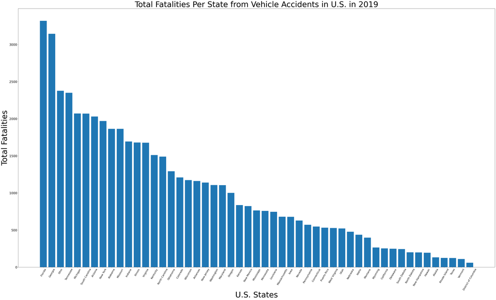

```python
plt.figure(figsize=(55,30))
plt.bar(combined_df["statename"], combined_df["fatalities"], width=0.8)
plt.xticks(fontsize=16, rotation=60)
plt.xlabel("U.S. States", fontsize=50)
plt.yticks(fontsize=20)
plt.ylabel("Total Fatalities", fontsize=50)
plt.title("Total Fatalities Per State from Vehicle Accidents in U.S. in 2019", fontsize=50)
plt.show()
```

To better represent the distribution of fatalities across states, we can group the states by regions (West, Midwest, East) and evaluate how regions have impacts on accident rates.

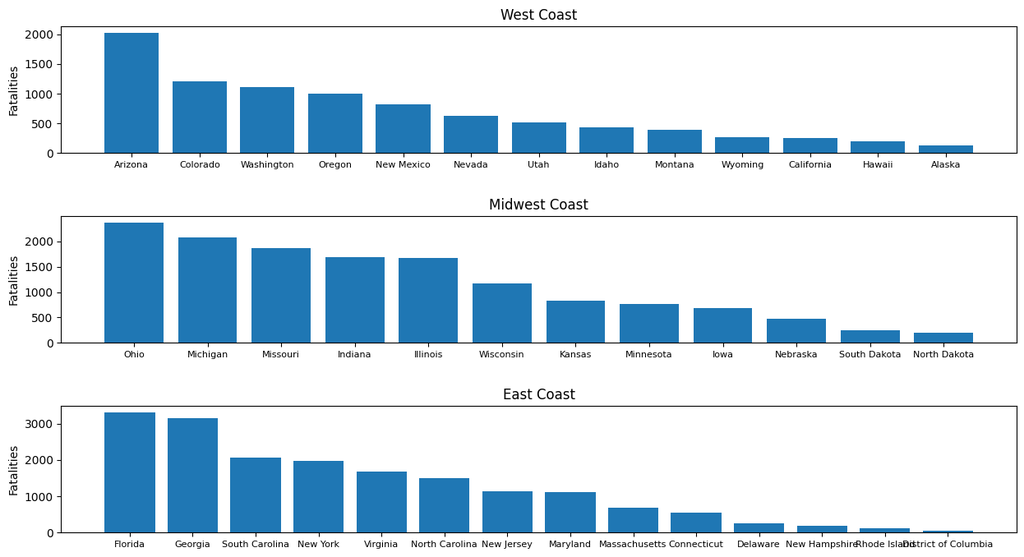

```python
west = ["Arizona", "Colorado", "Utah", "Nevada", "New Mexico", "Idaho", "Montana", "Wyoming", "California", "Washington", "Oregon", "Hawaii", "Alaska"]
midwest = ["Illinois", "Indiana", "Iowa", "Kansas", "Michigan", "Minnesota", "Missouri", "Nebraska", "North Dakota", "Ohio", "South Dakota", "Wisconsin"]
east = ["Connecticut", "Delaware", "Florida", "Georgia", "Maine", "Maryland", "Massachusetts", "New Hampshire", "New Jersey", "New York", "North Carolina", "Rhode Island", "South Carolina", "Virginia", "District of Columbia"]
west = combined_df[combined_df["statename"].isin(west)]
midwest = combined_df[combined_df["statename"].isin(midwest)]
east = combined_df[combined_df["statename"].isin(east)]

fig, axs = plt.subplots(3, figsize=(15,8))
axs[0].bar(west["statename"], west["fatalities"], width=0.8)
axs[0].tick_params("x", labelsize=8)
axs[0].set_ylabel("Fatalities")
axs[0].set_title("West Coast")
axs[1].bar(midwest["statename"], midwest["fatalities"], width=0.8)
axs[1].tick_params("x", labelsize=8)
axs[1].set_ylabel("Fatalities")
axs[1].set_title("Midwest Coast")
axs[2].bar(east["statename"], east["fatalities"], width=0.8)
axs[2].tick_params("x", labelsize=8)
axs[2].set_ylabel("Fatalities")
axs[2].set_title("East Coast")
plt.subplots_adjust(hspace=0.5)
plt.show()
```

Based on the distributions of each region, it appears that the West, Midwest, and East coasts appear to have similar distributions in accidents. We can create a violin plot to confirm our observations.

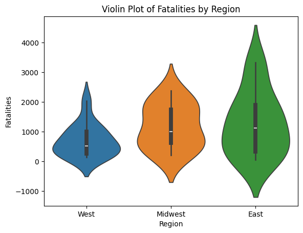

```python
data = {"West": west["fatalities"].values, "Midwest": midwest["fatalities"].values, "East": east["fatalities"].values}
sns.violinplot(data=data)
plt.xlabel("Region")
plt.ylabel("Fatalities")
plt.title("Violin Plot of Fatalities by Region")
plt.show()
```

Overall, each region has a similar distribution, but the east coast appears to have some outliers which result in a greater spread of values in general. This could be explained by many factors, especially considering Florida and Georgia are states in the east coast with a larger amount of accidents overall. Such factors may indicate that certain regions in the east coast are at greater risk of accidents.

Next, we will analyze crash ratings using the ratings dataframe and examine how fatalities are impacted by the quality of cars based on the cases provided.

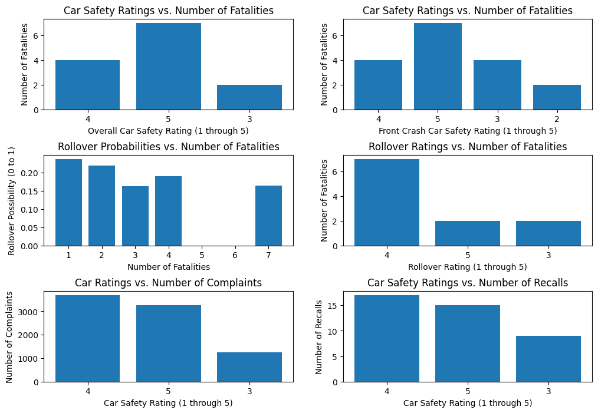

```python
plt.figure(figsize=(12,8))
plt.subplot(3,2,1)
plt.bar(ratings["OverallRating"], ratings["fatals"])
plt.xlabel("Overall Car Safety Rating (1 through 5)")
plt.ylabel("Number of Fatalities")
plt.title("Car Safety Ratings vs. Number of Fatalities")
plt.subplot(3,2,2)
plt.bar(ratings["OverallFrontCrashRating"], ratings["fatals"])
plt.xlabel("Front Crash Car Safety Rating (1 through 5)")
plt.ylabel("Number of Fatalities")
plt.title("Car Safety Ratings vs. Number of Fatalities")
plt.subplot(3,2,3)
plt.bar(ratings["fatals"], ratings["RolloverPossibility"])
plt.ylabel("Rollover Possibility (0 to 1)")
plt.xlabel("Number of Fatalities")
plt.title("Rollover Probabilities vs. Number of Fatalities")
plt.subplot(3,2,4)
plt.bar(ratings["RolloverRating"], ratings["fatals"])
plt.xlabel("Rollover Rating (1 through 5)")
plt.ylabel("Number of Fatalities")
plt.title("Rollover Ratings vs. Number of Fatalities")
plt.subplot(3,2,5)
plt.bar(ratings["OverallRating"], ratings["ComplaintsCount"])
plt.xlabel("Car Safety Rating (1 through 5)")
plt.ylabel("Number of Complaints")
plt.title("Car Ratings vs. Number of Complaints")
plt.subplot(3,2,6)
plt.bar(ratings["OverallRating"], ratings["RecallsCount"])
plt.xlabel("Car Safety Rating (1 through 5)")
plt.ylabel("Number of Recalls")
plt.title("Car Safety Ratings vs. Number of Recalls")
plt.subplots_adjust(hspace=0.5)
plt.show()
```

Finally, we can analyze each individual factor in the accidents_df and determine which factors appear to have the strongest correlation with accidents.

The frequencies of each label in cf1, cf2, and cf3 will be displayed below to demonstrate how certain factors are most prevalent in the accident cases.

```
1: Backup Due to Prior Crash
2: Date of Crash and Date of EMS Notification were not the same day
3: Inadequate Construction or Poor Design of Roadway,Bridge, etc.
4: Inadequate Warning of Exits, Lanes Narrowing, Traffic Controls, etc.
5: Indication of a Stalled/Disabled Vehicle
6: Motor Vehicle struck by falling cargo,or something that came loose from or something that was set in motion by a vehicle
7: No or Obscured Pavement Marking
8: Non-occupant struck by falling cargo, or something that came loose from, or something that was set in motion by a vehicle
9: Obstructed Crosswalks
10: Other Maintenance or Construction-Created Condition
11: Police Pursuit Involved
12: Prior Non-Recurring Incident
13: Recent/Previous Crash scene Nearby
14: Regular Congestion
15: Related to a Bus Stop
16: Reported as Unknown
17: Shoulder Design or Condition
18: Speed Limit is a Statutory Limit as Recorded or was determined as this state`s `basic rule`
19: Unstabilized Situation Began and All Harmful Events Occurred Off of the Roadway
20: Vehicle set-in-motion by non-driver
21: Within Designated School Zone
```

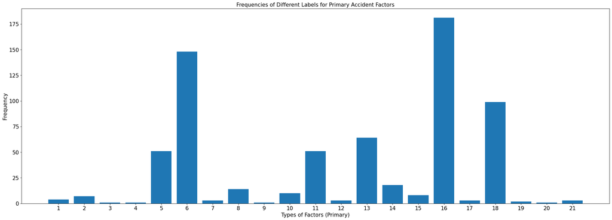

```python
plt.figure(figsize=((30,10)))
x = (list(accidents_df["cf1name"].values))
x = [str(i) for i in x]
x = [i for i in x if i != 'nan']
data, counts = np.unique(x, return_counts=True)
labels = [i+1 for i in range(len(data))]
for (i, j) in zip(labels, data):
    print(str(i) + ": " + j)
plt.bar(labels, counts)
plt.xticks(range(1,len(labels)+1), fontsize=15)
plt.xlabel("Types of Factors (Primary)", fontsize=15)
plt.title("Frequencies of Different Labels for Primary Accident Factors", fontsize=15)
plt.ylabel("Frequency", fontsize=15)
plt.yticks(fontsize=15)
plt.show()
```

Overall, most cases seem to feature motor vehicles being struck by cargo or loose parts from other vehicles, violations of speed limits recorded, and other unknown factors that may not be explained directly by the data itself.

```
1: Backup Due to Prior Crash
2: Indication of a Stalled/Disabled Vehicle
3: Motor Vehicle struck by falling cargo,or something that came loose from or something that was set in motion by a vehicle
4: Non-occupant struck by falling cargo, or something that came loose from, or something that was set in motion by a vehicle
5: Police Pursuit Involved
6: Recent/Previous Crash scene Nearby
7: Regular Congestion
8: Reported as Unknown
9: Speed Limit is a Statutory Limit as Recorded or was determined as this state`s `basic rule`
10: Unstabilized Situation Began and All Harmful Events Occurred Off of the Roadway
```

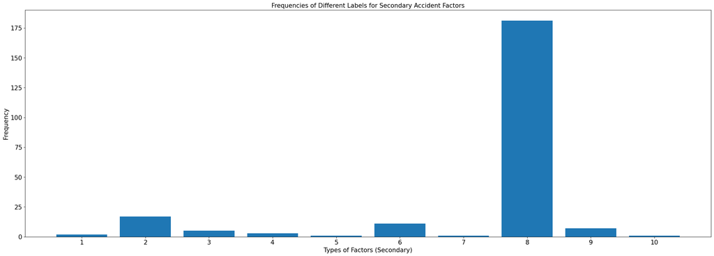

```python
plt.figure(figsize=((30,10)))
x = (list(accidents_df["cf2name"].values))
x = [str(i) for i in x]
x = [i for i in x if i != 'nan']
data, counts = np.unique(x, return_counts=True)
labels = [i+1 for i in range(len(data))]
for (i, j) in zip(labels, data):
    print(str(i) + ": " + j)
plt.bar(labels, counts)
plt.xticks(range(1,len(labels)+1), fontsize=15)
plt.xlabel("Types of Factors (Secondary)", fontsize=15)
plt.title("Frequencies of Different Labels for Secondary Accident Factors", fontsize=15)
plt.ylabel("Frequency", fontsize=15)
plt.yticks(fontsize=15)
plt.show()
```

In addition to the primary factors, some secondary factors, while not as prevalent, feature stalled/disabled vehicles, previous crashes nearby, speed limit violations, and other unknown factors.

```
1: Indication of a Stalled/Disabled Vehicle
2: Reported as Unknown
```

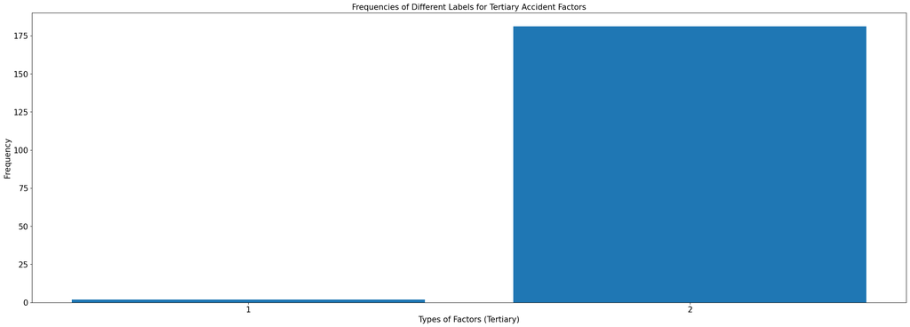

```python
plt.figure(figsize=((30,10)))
x = (list(accidents_df["cf3name"].values))
x = [str(i) for i in x]
x = [i for i in x if i != 'nan']
data, counts = np.unique(x, return_counts=True)
labels = [i+1 for i in range(len(data))]
for (i, j) in zip(labels, data):
    print(str(i) + ": " + j)
plt.bar(labels, counts)
plt.xticks(range(1,len(labels)+1), fontsize=15)
plt.xlabel("Types of Factors (Tertiary)", fontsize=15)
plt.title("Frequencies of Different Labels for Tertiary Accident Factors", fontsize=15)
plt.ylabel("Frequency", fontsize=15)
plt.yticks(fontsize=15)
plt.show()
```

Due to the nature of the data and inability to diagnose factors that played a significant role in crashes, most tertiary factors were reported as unknown. By performing data analysis, this project will allow us to explore different and unique factors that could not previously be explained.

We can also repeat the process on harm_evname, which is a list of the type of harmful environments where crashes occured. This can provide more insight in which types of areas could be avoided or regulated.

```
1: Boulder
2: Bridge Overhead Structure
3: Bridge Pier or Support
4: Bridge Rail (Includes parapet)
5: Building
6: Cable Barrier
7: Cargo/Equipment Loss, Shift, or Damage [harmful]
8: Concrete Traffic Barrier
9: Culvert
10: Curb
11: Ditch
12: Embankment
13: Fell/Jumped from Vehicle
14: Fence
15: Fire Hydrant
```

[output cut: 37 more lines]

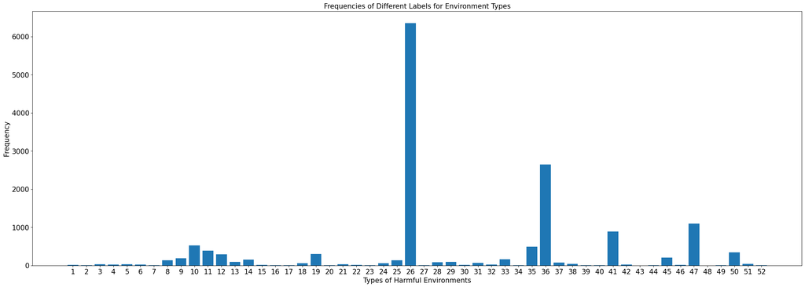

```python
plt.figure(figsize=((30,10)))
x = (list(accidents_df["harm_evname"].values))
x = [str(i) for i in x]
x = [i for i in x if i != 'nan']
data, counts = np.unique(x, return_counts=True)
labels = [i+1 for i in range(len(data))]
for (i, j) in zip(labels, data):
    print(str(i) + ": " + j)
plt.bar(labels, counts)
plt.xticks(range(1,len(labels)+1), fontsize=15)
plt.xlabel("Types of Harmful Environments", fontsize=15)
plt.title("Frequencies of Different Labels for Environment Types", fontsize=15)
plt.ylabel("Frequency", fontsize=15)
plt.yticks(fontsize=15)
plt.show()
```

The most harmful environments in the total crash cases appear to be motor vehicles in-transport (general vehicles on the roadway), pedestrian environments, and trees (stationary).

Next, we will plot unique features from the accidents_df and compare them to the number of fatal accidents in order to determine which factors correlate the most to severe accidents.

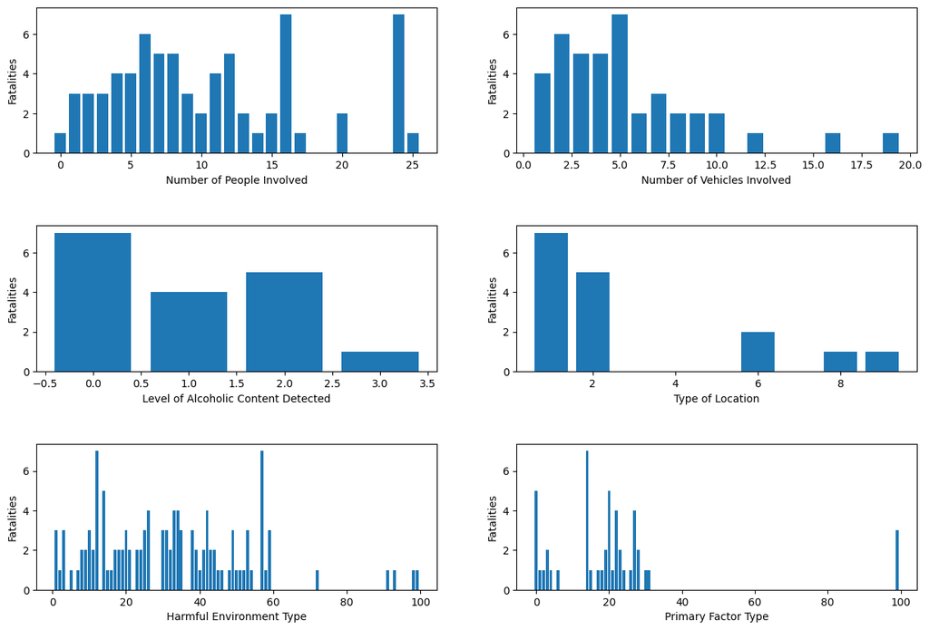

```python
plt.figure(figsize=(15,10))
plt.subplot(3,2,1)
plt.bar(accidents_df["persons"], accidents_df["fatals"])
plt.xlabel("Number of People Involved")
plt.ylabel("Fatalities")

plt.subplot(3, 2, 2)
plt.bar(accidents_df["ve_total"], accidents_df["fatals"])
plt.xlabel("Number of Vehicles Involved")
plt.ylabel("Fatalities")

plt.subplot(3, 2, 3)
plt.bar(accidents_df["drunk_dr"], accidents_df["fatals"])
plt.xlabel("Level of Alcoholic Content Detected")
plt.ylabel("Fatalities")

plt.subplot(3, 2, 4)
plt.bar(accidents_df["rur_urb"], accidents_df["fatals"])
plt.xlabel("Type of Location")
plt.ylabel("Fatalities")

plt.subplot(3, 2, 5)
plt.bar(accidents_df["harm_ev"], accidents_df["fatals"])
plt.xlabel("Harmful Environment Type")
plt.ylabel("Fatalities")

plt.subplot(3, 2, 6)
plt.bar(accidents_df["cf1"], accidents_df["fatals"])
plt.xlabel("Primary Factor Type")
plt.ylabel("Fatalities")
plt.subplots_adjust(hspace=0.5)

plt.show()
```

Finally, we can plot the relative fatality rates of each case by calculating the number of people involved in each case, defined by the number of people in vehicles, pedestrians, and other situations in the case, and dividing the number of fatalities by the calculated number of people. These rates can provide more indication of the severity of the crashes and feature more unique values that offer more insights into how classification can be made by the model. The dataframe will append a column of these rates for processing.

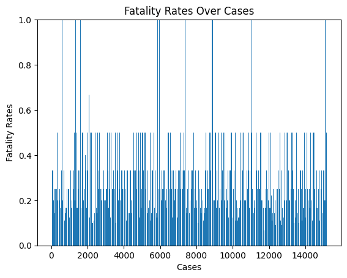

```python
fatals = []
people = []
# Collect the number of fatals and total number of people for each case; note fatals appears the same for each case, but people will need
# to be summed as the number of people is different per case
for case in accidents_df["st_case"]:
    fatals.append(min(accidents_df[accidents_df["st_case"] == case]["fatals"].values))
    people.append(accidents_df[accidents_df["st_case"] == case]["persons"].sum())
rate = np.array(fatals) / np.array(people)
accidents_df["rate"] = rate
# Filter columns in the df to exclude erroneous cases where fatalities are reported higher than the total number of people present
accidents_df = accidents_df[accidents_df["rate"] <= 1.0]
plt.bar(range(len(rate)), rate)
plt.xlabel("Cases")
plt.ylabel("Fatality Rates")
plt.title("Fatality Rates Over Cases")
plt.ylim(0,1)
plt.show()
```

# Hypothesis Testing

**Classification**

Overall, based on data exploration and visualization, we anticipate the number of people, number of vehicles, level of alcoholic content, type of location, level of harmful environment, and primary factor (cf1) to be the most significant factors that contribute to the severity of car crashes in the United States. To perform a hypothesis test, we will utilize Multinomial Logistic Regression, which performs classification for more than 2 output classes, and we will retrieve the relevant p values for each class corresponding to each factor. With these statistics, we will be able to determine if certain factors are significant enough to include in our classification models.

```python
warnings.filterwarnings("ignore")
# Drop all columns of the dataframe that have categorical values. We will use the numerical values associated with them.
factors = accidents_df.drop(columns=["statename", "state", "st_case", "hourname", "harm_evname", "man_collname", "cf1name", "cf2name", "cf3name", "cf2", "cf3", "road_fnc", "rail"])
# Since we are focusing on cf1, we will drop all NaN occurrences.
factors = factors.dropna(subset=["cf1"])
# Add a constant to the columns of the df to provide for logistic regression
factors["constant"] = 1
# This function will be applied to the rate column of the dataframe to create a new column called severity that provides the true class measurement
# of each column. Fatality rates below 0.2 receive a rating of 0 (least severe), while 1 is from 0.2 to 0.4 for moderate and anything above 0.4
# is considered severe (2).
def classify_severity(rate):
    if rate <= 0.2:
        return 0
    elif rate <= 0.4:
        return 1
    else:
        return 2

factors['severity'] = factors['rate'].apply(classify_severity)
predictors = list(factors.columns)
predictors.remove("rate")
predictors.remove("severity")
# We will use statsmodels to fit the columns of our dataset and output the corresponding p values and other statistics for each feature.
test = sm.MNLogit(factors["severity"], factors[predictors])
res = test.fit(method="bfgs")
print(res.summary())
```

```
         Current function value: 0.773563
         Iterations: 35
         Function evaluations: 39
         Gradient evaluations: 39
                          MNLogit Regression Results
==============================================================================
Dep. Variable:               severity   No. Observations:                 7313
Model:                        MNLogit   Df Residuals:                     7273
Method:                           MLE   Df Model:                           38
Date:                Sat, 18 May 2024   Pseudo R-squ.:                  0.2596
Time:                        01:29:47   Log-Likelihood:                -5657.1
converged:                      False   LL-Null:                       -7640.2
Covariance Type:            nonrobust   LLR p-value:                     0.000
==============================================================================
severity=1       coef    std err          z      P>|z|      [0.025      0.975]
------------------------------------------------------------------------------
ve_total       0.3626      0.071      5.090      0.000       0.223       0.502
pvh_invl      -0.0840      0.205     -0.410      0.682      -0.486       0.318
peds          -0.1195      0.332     -0.359      0.719      -0.771       0.532
pernotmvit     0.0081      0.321      0.025      0.980      -0.621       0.637
persons       -1.1921      0.043    -27.498      0.000      -1.277      -1.107
typ_int     8.264e-05      0.011      0.007      0.994      -0.022       0.022
wrk_zone       0.0211      0.076      0.277      0.782      -0.128       0.171
nhs            0.2061      0.064      3.245      0.001       0.082       0.331
rur_urb        0.2684      0.064      4.203      0.000       0.143       0.394
hour           0.0040      0.003      1.228      0.219      -0.002       0.010
sp_jur         0.0316      0.234      0.135      0.893      -0.428       0.491
harm_ev        0.0088      0.003      2.992      0.003       0.003       0.015
man_coll      -0.0010      0.008     -0.118      0.906      -0.018       0.016
weather1      -0.0033      0.005     -0.700      0.484      -0.012       0.006
weather2       0.0317      1.641      0.019      0.985      -3.184       3.247
sch_bus        0.0460      0.513      0.090      0.929      -0.960       1.052
cf1            0.0023      0.002      1.197      0.231      -0.001       0.006
fatals         0.6430      0.097      6.649      0.000       0.453       0.833
drunk_dr       0.1750      0.072      2.422      0.015       0.033       0.317
constant       0.8339      0.200      4.171      0.000       0.442       1.226
------------------------------------------------------------------------------
severity=2       coef    std err          z      P>|z|      [0.025      0.975]
------------------------------------------------------------------------------
ve_total       0.5785      0.199      2.903      0.004       0.188       0.969
pvh_invl       0.1075      0.304      0.354      0.723      -0.487       0.702
peds           0.0874      0.759      0.115      0.908      -1.400       1.575
pernotmvit    -0.0763      0.750     -0.102      0.919      -1.545       1.393
persons       -3.2857      0.142    -23.081      0.000      -3.565      -3.007
typ_int        0.0011      0.016      0.069      0.945      -0.031       0.033
wrk_zone      -0.0094      0.106     -0.089      0.929      -0.217       0.199
nhs            0.2415      0.088      2.744      0.006       0.069       0.414
rur_urb        0.3301      0.087      3.812      0.000       0.160       0.500
hour           0.0002      0.004      0.042      0.967      -0.008       0.008
sp_jur         0.0273      0.257      0.106      0.916      -0.477       0.532
harm_ev        0.0121      0.004      3.375      0.001       0.005       0.019
man_coll      -0.0460      0.036     -1.262      0.207      -0.117       0.025
weather1      -0.0069      0.006     -1.220      0.222      -0.018       0.004
weather2      -0.0239      1.680     -0.014      0.989      -3.316       3.268
sch_bus        0.0497      1.082      0.046      0.963      -2.070       2.170
cf1           -0.0024      0.003     -0.889      0.374      -0.008       0.003
fatals         1.4783      0.215      6.872      0.000       1.057       1.900
drunk_dr       0.4146      0.100      4.151      0.000       0.219       0.610
constant       1.5503      0.331      4.690      0.000       0.902       2.198
==============================================================================
```

According to the summary of the multinomial logistic regression, it appears that the most statistically significant factors (where we can reject the null hypothesis that there is no association between that feature and severity) for a significance level of 0.05 are:

# Machine Learning

**Classification**

```python
# Create a model dataframe that removes the intercept from above and drops the columns with the least significance reported from the
# hypothesis test
model_df = factors.drop("constant", axis=1)
X = model_df.drop(columns=["severity", "peds", "pernotmvit", "typ_int", "hour", "sp_jur", "weather2", "sch_bus", "cf1", "severity"], axis=1)
y = model_df["severity"]
# Perform a train test split where the test set is 30% of the original dataset size and y values are the severity classifications
X_train, X_test, y_train, y_test = train_test_split(X, y, test_size=0.3)
```

The first model we will use is a Support Vector Machine, which is a model that creates a hyperplane between class labels and attempts to maximize the margins between these classes in order to successfully distinguish each data point into its respective class. The SVM can be used here to place each feature into a class label.

```python
# A StandardScaler is used to perform appropriate scaling on the feature labels of the X values in order to eliminate large discrepancies between data
# points, which will assist with operations
scaler = StandardScaler()
X_train = scaler.fit_transform(X_train)
X_test = scaler.transform(X_test)

# A Support Vector Machine is created with a Radial Basis Function, which is a popular kernel for SVM problems
model = SVC(kernel='rbf')

# The model is fit on the X_train and y_train values and will output y_pred, which is an output of all predicted class labels for each
# data point
model.fit(X_train, y_train)
y_pred = model.predict(X_test)

print("Mean squared error", mean_squared_error(y_pred, y_test))
print("Accuracy:", accuracy_score(y_test, y_pred))
```

```
Mean squared error 0.007292616226071103
Accuracy: 0.9927073837739289
```

Another popular classification model is K Nearest Neighbors, which utilizes distance metrics such as Euclidean Distance to store data points from a training set and determine how class an unclassified point is from an existing class label. The model will select the class label that corresponds to the majority class of the closest k neighbors.

```python
# We will perform KNN for a neighbor count of 1 to 10 to compare relative accuracies when the parameters of the model are altered
for i in range(1, 11):
    print("k= ", i)
    model = KNeighborsClassifier(n_neighbors=i)
    model.fit(X_train, y_train)

    # Predict and evaluate
    y_pred = model.predict(X_test)
    print("Mean squared error", mean_squared_error(y_test, y_pred))
    print("Accuracy:", accuracy_score(y_test, y_pred))
```

```
k=  1
Mean squared error 0.059708295350957154
Accuracy: 0.9430264357338195
k=  2
Mean squared error 0.07338195077484047
Accuracy: 0.9279854147675478
k=  3
Mean squared error 0.06973564266180492
Accuracy: 0.9343664539653601
k=  4
Mean squared error 0.07247037374658159
Accuracy: 0.9288969917958068
k=  5
Mean squared error 0.06882406563354604
Accuracy: 0.9339106654512306
k=  6
Mean squared error 0.07019143117593436
Accuracy: 0.931175934366454
k=  7
Mean squared error 0.07064721969006381
Accuracy: 0.9307201458523245
k=  8
Mean squared error 0.07566089334548769
Accuracy: 0.9257064721969006
k=  9
Mean squared error 0.07429352780309936
Accuracy: 0.9257064721969006
k=  10
Mean squared error 0.07839562443026436
Accuracy: 0.922971741112124
```

**Regression**

During this phase of the Data Lifecycle, we attempt to perform polynomial regression in order to obtain a predictive model of our data. This allows us to predict values for data outside of the scope of our data. For example, we can use a linear regression model to predict how crash fatalities will increase or decrease for the next year of 2020, which is exactly what we are going to attempt to do below.

```python
pred_df = crashes_df
pred_df['crashdate'] = pd.to_datetime(pred_df['crashdate'], errors='coerce')
pred_df = pred_df.dropna(subset=['crashdate']).copy()
pred_df.loc[:, 'crashdate'] = pred_df['crashdate'].apply(lambda x: pd.Timestamp(year=2019, month=x.month, day=1))

pred_df = pred_df[['crashdate', 'state', 'statename', 'fatals']]
pred_df.head()
```

|  | crashdate | state | statename | fatals |
| --- | --- | --- | --- | --- |
| 0 | 2019-11-01 | 1 | Alabama | 1 |
| 1 | 2019-10-01 | 1 | Alabama | 1 |
| 2 | 2019-11-01 | 1 | Alabama | 1 |
| 3 | 2019-10-01 | 1 | Alabama | 1 |
| 4 | 2019-10-01 | 1 | Alabama | 1 |

```python
# Convert 'crashdate' column to NumPy datetime64
crashdate_np = pd.to_datetime(pred_df['crashdate']).values.astype('datetime64[D]')

# Convert 'state' column to NumPy array
state_np = pred_df['state'].values.astype(np.int32)

# Convert 'statename' column to NumPy array
statename_np = pred_df['statename'].astype(str).values

# Convert 'fatals' column to NumPy array
fatals_np = pred_df['fatals'].values.astype(np.int32)

# Combine arrays into one NumPy array
combined_np = np.column_stack((crashdate_np, state_np, statename_np, fatals_np))

combined_np
```

```
array([[datetime.date(2019, 11, 1), 1, 'Alabama', 1],
       [datetime.date(2019, 10, 1), 1, 'Alabama', 1],
       [datetime.date(2019, 11, 1), 1, 'Alabama', 1],
       ...,
       [datetime.date(2019, 11, 1), 56, 'Wyoming', 1],
       [datetime.date(2019, 11, 1), 56, 'Wyoming', 1],
       [datetime.date(2019, 11, 1), 56, 'Wyoming', 1]], dtype=object)
```

Below is our polynomial regression model to predict the fatalities for each state in the upcoming 2020 calendar year. We use a non-negative constraint to make sure values don't go below 0 (vehicular crashes don't create lives after all!).

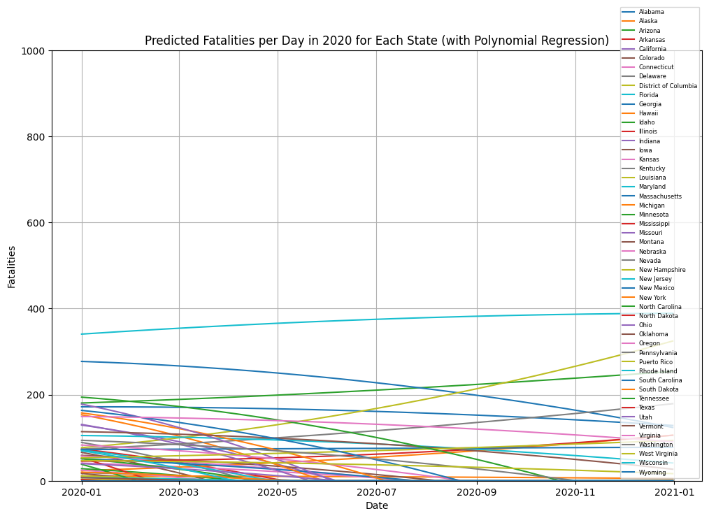

```
Mean Squared Error (MSE): 201.48672734370837
```

```python
### Suppress some unwanted warnings that don't affect code functionality to make it look more readable
warnings.filterwarnings("ignore")

# Convert to DataFrame
df = pd.DataFrame(combined_np, columns=['Date', 'State_ID', 'State_Name', 'Fatalities'])

# Convert Date to ordinal (numeric representation)
df['Date'] = pd.to_datetime(df['Date']).apply(lambda x: x.toordinal())

# Aggregate fatalities by date and state
aggregated_df = df.groupby(['Date', 'State_Name']).sum().reset_index()

# Generate dates for 2020
dates_2020 = pd.date_range(start='2020-01-01', end='2020-12-31')

# Initialize an empty DataFrame to store predicted fatalities for each state
predicted_fatalities_2020_all_states = pd.DataFrame(index=dates_2020)

# Initialize variables to store metrics
mse_list = []

# Iterate over each state
for state in df['State_Name'].unique():
    # Filter data for the current state
    state_df = aggregated_df[aggregated_df['State_Name'] == state]

    # Extract features and target variable
    X = state_df[['Date']].values
    y = state_df['Fatalities'].values

    # Train the polynomial regression model for the current state
    model = make_pipeline(PolynomialFeatures(degree=3), LinearRegression())
    model.fit(X, y)

    # Convert dates for 2020 to ordinal
    X_2020 = pd.DataFrame({'Date': dates_2020})
    X_2020['Date'] = X_2020['Date'].apply(lambda x: x.toordinal())

    # Predict fatalities for 2020 for the current state
    predicted_fatalities_2020 = model.predict(X_2020[['Date']])

    # Set negative predictions to 0
    predicted_fatalities_2020[predicted_fatalities_2020 < 0] = 0

    # Calculate Mean Squared Error
    mse = mean_squared_error(y, model.predict(X))
    mse_list.append(mse)

    # Add predicted fatalities to the DataFrame for all states
    predicted_fatalities_2020_all_states[state] = predicted_fatalities_2020

# Plot the results
plt.figure(figsize=(12, 8))
for state in predicted_fatalities_2020_all_states.columns:
    plt.plot(dates_2020, predicted_fatalities_2020_all_states[state], label=state)
plt.xlabel('Date')
plt.ylabel('Fatalities')
plt.title('Predicted Fatalities per Day in 2020 for Each State (with Polynomial Regression)')
plt.legend(fontsize='6')
plt.grid(True)
plt.ylim(0,1000)
plt.show()
# Display MSE and other statistics
print("Mean Squared Error (MSE):", np.mean(mse_list))
```

```python
total_predicted_deaths_2020 = predicted_fatalities_2020_all_states.sum(axis=0).astype(int)

t2020_total_df = pd.DataFrame(total_predicted_deaths_2020, columns=['Total Predicted Deaths'])
t2020_total_df.head()
```

|  | Total Predicted Deaths |
| --- | --- |
| Alabama | 57587 |
| Alaska | 3281 |
| Arizona | 77888 |
| Arkansas | 5022 |
| California | 2339248 |

```python
# Alabama, Alaska, Arizona, Arkansas, California
response = requests.get("https://crashviewer.nhtsa.dot.gov/CrashAPI/crashes/GetCaseList?states=1,2,4,5,6&fromYear=2020&toYear=2021&minNumOfVehicles=1&maxNumOfVehicles=6&format=csv")
crashes1_df2 = pd.read_csv(StringIO(response.text))
# Colorado, Connecticut, Delaware, District of Columbia, Florida, Georgia
response = requests.get("https://crashviewer.nhtsa.dot.gov/CrashAPI/crashes/GetCaseList?states=8,9,10,11,12&fromYear=2020&toYear=2021&minNumOfVehicles=1&maxNumOfVehicles=6&format=csv")
crashes2_df2 = pd.read_csv(StringIO(response.text))
#Georgia, Hawaii, Idaho, Illinois
response = requests.get("https://crashviewer.nhtsa.dot.gov/CrashAPI/crashes/GetCaseList?states=13,15,16,17&fromYear=2020&toYear=2021&minNumOfVehicles=1&maxNumOfVehicles=6&format=csv")
crashes3_df2 = pd.read_csv(StringIO(response.text))
#Indiana, Iowa, Kansas, Kentucky, Louisiana
response = requests.get("https://crashviewer.nhtsa.dot.gov/CrashAPI/crashes/GetCaseList?states=18,19,20,21,22,23&fromYear=2020&toYear=2021&minNumOfVehicles=1&maxNumOfVehicles=6&format=csv")
crashes4_df2 = pd.read_csv(StringIO(response.text))
#Maryland, Massachusetts, Michigan, Minnesota, Mississippi
response = requests.get("https://crashviewer.nhtsa.dot.gov/CrashAPI/crashes/GetCaseList?states=24,25,26,27,28&fromYear=2020&toYear=2021&minNumOfVehicles=1&maxNumOfVehicles=6&format=csv")
crashes5_df2 = pd.read_csv(StringIO(response.text))
#Missouri, Montana, Nebraska, Nevada, New Hampshire
response = requests.get("https://crashviewer.nhtsa.dot.gov/CrashAPI/crashes/GetCaseList?states=29,30,31,32,33&fromYear=2020&toYear=2021&minNumOfVehicles=1&maxNumOfVehicles=6&format=csv")
crashes6_df2 = pd.read_csv(StringIO(response.text))
#New Jersey, New Mexico, New York, North Carolina
response = requests.get("https://crashviewer.nhtsa.dot.gov/CrashAPI/crashes/GetCaseList?states=34,35,36,37&fromYear=2020&toYear=2021&minNumOfVehicles=1&maxNumOfVehicles=6&format=csv")
crashes7_df2 = pd.read_csv(StringIO(response.text))
# North Dakota, Ohio, Oklahoma, Oregon, Pennsylvania
response = requests.get("https://crashviewer.nhtsa.dot.gov/CrashAPI/crashes/GetCaseList?states=38,39,40,41,42&fromYear=2020&toYear=2021&minNumOfVehicles=1&maxNumOfVehicles=6&format=csv")
crashes8_df2 = pd.read_csv(StringIO(response.text))
#Puerto Rico, Rhode Island, South Carolina, South Dakota, Tennessee, Texas
response = requests.get("https://crashviewer.nhtsa.dot.gov/CrashAPI/crashes/GetCaseList?states=43,44,45,46,47,48&fromYear=2020&toYear=2021&minNumOfVehicles=1&maxNumOfVehicles=6&format=csv")
crashes9_df2 = pd.read_csv(StringIO(response.text))
#Utah, Vermont, Virginia, Virgin Islands, Washington, West Virginia, Wisconsin, Wyoming
response = requests.get("https://crashviewer.nhtsa.dot.gov/CrashAPI/crashes/GetCaseList?states=49,50,51,52,53,54,55,56&fromYear=2020&toYear=2021&minNumOfVehicles=1&maxNumOfVehicles=6&format=csv")
crashes10_df2 = pd.read_csv(StringIO(response.text))

crashes_df2 = pd.concat([crashes1_df2, crashes2_df2, crashes3_df2, crashes4_df2, crashes5_df2, crashes6_df2, crashes7_df2, crashes8_df2, crashes9_df2, crashes10_df2],
                       ignore_index=True)
```

```python
combined_df2 = pd.DataFrame()

state_ids2 = []
statenames2 = []
sums2 = []

state_ids2 = (crashes_df2["state"].unique())
statenames2 = (crashes_df2["statename"].unique())
for state in state_ids2:
    sums2.append(crashes_df2[crashes_df2["state"] == state]["fatals"].sum())

sums2 = [x for x in sums2 if x != 0]
combined_df2["state_id"] = state_ids
combined_df2["statename"] = statenames
combined_df2["fatalities"] = sums
combined_df2 = combined_df2.sort_values(by="statename", ascending=True)
combined_df2[0:10]
```

|  | state_id | statename | fatalities |
| --- | --- | --- | --- |
| 0 | 1 | Alabama | 1864 |
| 1 | 2 | Alaska | 131 |
| 2 | 4 | Arizona | 2029 |
| 3 | 5 | Arkansas | 1161 |
| 4 | 6 | California | 252 |
| 5 | 8 | Colorado | 1208 |
| 6 | 9 | Connecticut | 547 |
| 7 | 10 | Delaware | 248 |
| 8 | 11 | District of Columbia | 59 |
| 9 | 12 | Florida | 3319 |

For more information on using the classification and regression models above, please visit:

- [Support Vector Machines Documentation](https://scikit-learn.org/stable/modules/svm.html)
- [K Nearest Neighbors Documentation](https://scikit-learn.org/stable/modules/generated/sklearn.neighbors.KNeighborsClassifier.html)
- [About Polynomial Linear Regression](https://medium.com/analytics-vidhya/understanding-polynomial-regression-5ac25b970e18)

# Insights and Discoveries

Overall, we were able to successfully execute the entire data science pipeline, from data curation to machine learning anaylsis.

To improve future predictions and classifications on unseen data, we can:

1. Extend our dataset to include data from more years to understand how deaths fluctuate seasonally. This would help mitigate the impact of any year-specific trends, as well as mitigate some of the outliers produced from just our 1-year sample.
2. Include holiday timings as a feature, as increased travel often leads to more vehicle usage and, subsequently, more fatalities.
3. Employ more sophisticated models beyond polynomial regression to better capture complex trends, especially if we use the other features mentioned above.
4. Accumulate data from more time periods to capture trends in fatality severities over the years when building the classification models.

Overall, through data analysis on vehicular accidents, decisions and policies related to road safety and laws can be better informed.